# Stats Notes

# Stats Notes

## Conditional probability - Bayes Rule

- $P(A)$ - the probability of A occuring
- $P(A \cap B)$ - the intersection - the probability of both $A$ and $B$ occuring
- $P(A \cup B)$ - the union - the probability of $A$ or $B$ (or both) occuring

## Bayes rule

Bayes rule allows us to invert the condition on a conditional probablility. That is, if we know the probability of $B$ given $A$, then we can infer the probability of $A$ when $B$ is satisfied/given/present.

$$\begin{aligned}
P(A|B) &= \frac{P(B|A)P(A)} { P(B) } \\\
P(A|B) &= \frac{P(B|A)P(A)} { P(B|A)P(A) + P(B|A^c)P(A^c) }
\end{aligned}$$

Consider a diagnostic test. We can assess the test for sensitivity and specificity (see below), which describe how the test behaves in the presence of the disease. After taking the test, however, we are probably more interested in inverting this relationship - what is the probability of having the disease given the test was positive?

In this case, $A$ is a condition (or disease), whereas $B$ is an observation (the state of a test - positive or negative)

Bayes rule gives the probability of having the disease given a positive test:

$$\begin{aligned}
P(A|B) &= \frac{P(B|A) P(A)}{ P(B|A) P(A) + P(B|A^c) P(A^c)}\\\
P(A|B) &= \frac{P(B|A) P(A)}{ P(B|A) P(A) + (1-P(B^c|A^c))(1-P(A))}
\end{aligned}$$

## Distributions

### Bernoulli

coin flip. Outcome is 0 (failure) or 1 (success), with probability of success p probability mass function is
$$P(x) = p^x(1-p)^{1-x}$$

### Normal

gaussian

### Exponential

discrete and continuous forms

## Variance and stuff

### Bessel’s correction

standard deviaion is defined variance is defined as $\sum((x_i - (\bar{x})^2)/\sqrt{n-1}$. This is to avoid bias. The population variance is given by $\sum_i (x_i -\mu)^2/N$. In reality, we do not know $\mu$, only the sample mean $\bar{x}$, so we compute the sample variance using $\bar{x}$ instead of $\mu$. While the sample mean is an unbiased estimator of the population mean, there is some uncertainty in it. The effect of using the sample mean instead of the population mean is to decrease the variance. What we want is the some of the squared distances from the population mean, but we end up using the sum of squared distances from the sample mean. The sample mean can be shown to be that value that minimises the sum of squared distances, and thus using it will always underestimate the population variance (unless the sample mean happens to be equal to the population mean)

### standard error of the mean

The variance of the sample mean is given by

$$var(\bar{X}) = \frac{sigma^2}{n}$$

Even though we don’t know the population variance ($\sigma^2$), the sample variance ($S^2$) is an unbiased estimate of this, so we can get a pretty good idea.

The standard deviation of the sample mean is then given by
$$\begin{aligned}
sd(\bar{X}) &= \frac{sigma}{\sqrt{n}} \\
&\approx \frac{S}{\sqrt{n}} \\
\end{aligned}$$

In general, the standard deviation of a statistic is called the standard error of that statistic. ## Confidence Intervals

### normal confidence intervals

### t statistics and confidence intervals

## hypothesis testing

Hypothesis testing is used to determine whether or not a measurement is statistically significant. For example, we might measure a mean value to be $\bar{X} = 0.1$, and want to know if this mean is close enough to or appreciably different from a mean of zero.

In hypothesis testing, a null hypothesis is compared to an alternate hypothesis. The null hypothesis is usually something along the lines of “there is no difference between those two samples”, “the population mean is equal to zero”, etc. It supposes that there is no underlying feature in the data, and that any variation is only due to statistical fluctuations. The alternate hypothesis supposes that there **is** some underlying feature in the data, such as a nonzero difference or mean. The alternate hypothesis may either be one sided (“the population mean is greater than Y” or “the population mean is less than Y”), or two sided (“the population mean is not equal to Y”). The null hypothesis is assumed by default, we require a certain threshold of significance from our data in order to overturn the null hypothesis and instead accept the alternate hypothesis.

For example, we might want to be at least 95% certain that the population mean is greater than some threshold. To start, we assume the null hypothesis (that the population mean is equal to our threshold). We then calculate the probability that the underlying population distribution could produce a sample with mean that we observed. We compute an appropriate statistic (either the t-statistic or the z-statistic, or something else) of our sample mean under the null hypothesis.

### Error types

A type I error is incorrectly rejecting the null hypothesis (a false positive). In cases where the null hypothesis is actually true, it will still be rejected with probability $(1-\alpha)$, where $\alpha$ is the value of the confidence interval being used.

A type II error is where we incorrectly accept the null hypothesis (a false negative). ## Power

Say we have a sample, and two hypotheses: $H_0: \mu = \mu_0$ and $H_A: mu > mu_0$. The statistical power is the probability of rejecting the null hypothesis, for a given scenario (e.g $\mu = \mu_\alpha, n = 1000$, etc.). To reject the null, the test statistic needs to lie outside our confidence interval. Power is the probability that this will occur if the alternate hypothesis is true, that is , it is the probability that the alternate hypothesis will generate a test statistic outside of the null hypothesis’s confidence interval.

If the distributions of the test statistics are narrow and well seperated, then there should be quite a lot of power (the alternate scenario is unlkely to produce a statistic inside the null’s confidence interval), something close to 100%. If the distributions are seperated but broad, then there is some probabilty of the alternate scenario yielding a statistic inside the null’s interval.

# Regression Models

## Residual Stuff

### leverage and influence

Can be more specific than just calling something an outlier. Leverage is how far a datapoint’s $x$ coordinate is from the mean $\bar{x}$, things further away can potentially affect the regression more. Influence is whether or not an outlying point is trying to pull the fit away from the other points. If a point has leverage, and its associated $y$ coordinate is significantly different from what the regression would predict were that point absent, then the point is using its leverage to exert *influence* on the fit. leverage is the potential to alter the regression, influence is whether or not it does. A point with little leverage can’t have much influence.

`?influence.measures` gives info on R commands to quantify outliers/influence/leverage.

Residuals can be normalised using the functions `rstandard` and `rstudent` . Influence is measured by removing points from the dataset and rerunning the regression.

The functions `dffits` and `dfbetas` are also interesting

some diagnostic plots can be shown by passing the lm object directly to the plot function - `?plot.lm` has more details. There are six available plots, which can be selected using the “which” argument in the plot call.

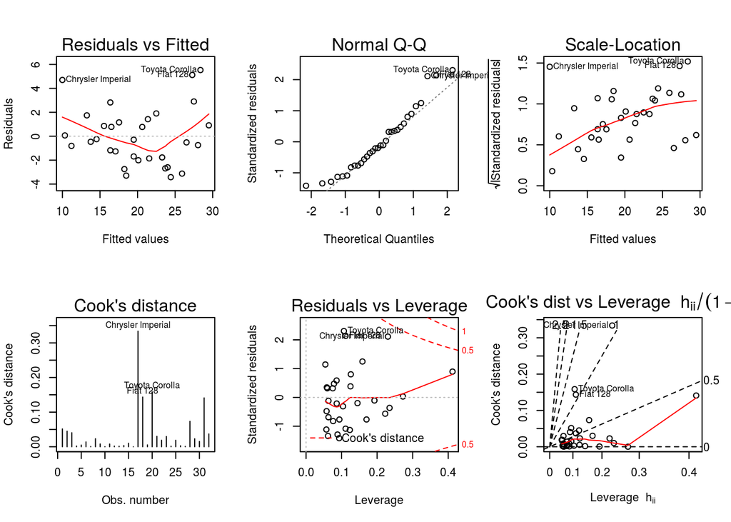

```r
moose<-lm(data=mtcars,formula=mpg~wt + factor(am) + hp)
par(mfrow=c(2,3))
g<-plot(moose,which=1:6)
```

```r
print(g)
```

The plot of the residuals vs the fitted values, in particular, is pretty useful. Anything that looks systematic there can be an indication of a fault/defficiency in the model.

## Generalised Linear Models

instead of transforming data and then applying a linear model, generalised linear models include any data transformation, so can work directly with observed data. In a linear model, we attempt to describe the regressor as a linear function of the predictors. In GLMs, we essentially essentiall model some function of the variable as a linear function of the predictors. There is then some math to determine the expected value (mean) of the variable of interest and it’s variance, etc.

have three things

- An exponential family model for the variation in the response
- A systematic component (a linear predictor)
- A link function that connects the means of the response to the predictor

In the bernouli example, The response is assumed to follow a Bernoulli distribution $E[Y_i] = \mu_i$, where $0 \leq \mu_i \leq 1$. The predictor is $\eta$, which is treated as a linear variable. The link function $g(\mu) = \eta$ give $\eta$ as a function of $\mu$. For the Bernoulli case, the link function $\eta = g(\mu) = \mathrm{log}\frac{\mu}{1-\mu}$ maps $\mu$ (which runs from 0 to 1) to $\eta$ (which runs from $-\infty$ to $\infty$)